# Machine Learning Project: Activity

Lucas Fernandez

2 de marzo de 2018

## Exploring the data

First we start by loading the data and having a look at the data frame:

```r
set.seed(1564)

library(corrplot);
library(caret);
library(rpart);
library(rpart.plot);
library(rattle);
library(gridExtra);
library(reshape2);

if (!file.exists("training.csv")) {
  download.file("http://d396qusza40orc.cloudfront.net/predmachlearn/pml-training.csv",
                destfile = "training.csv")
}
if (!file.exists("testing.csv")) {
  download.file("http://d396qusza40orc.cloudfront.net/predmachlearn/pml-testing.csv",
                destfile = "testing.csv")
}

training <- read.csv("training.csv", header = TRUE, na.strings = c("NA",""))
testing <- read.csv("testing.csv", header = TRUE, na.strings = c("NA",""))

dim(training)
```

```
## [1] 19622   160
```

A simple visualization shows a lot of empty columns. Also, reading the article suggest that variables such as time order and name may introduce artifacts (whether due to design or exhaustion) and those variables should be discarded:

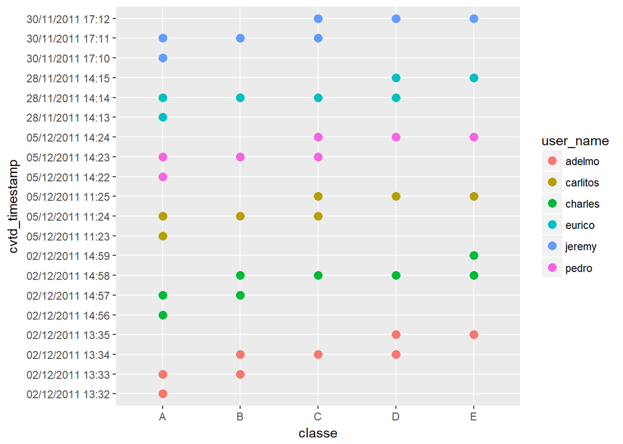

```r
qplot(classe, cvtd_timestamp, data=training, color=user_name, size=I(3))
```

We will trim these variables, and also those with NAs:

```r
training_filter_col <- training[,(colSums(is.na(training)) == 0)]
testing_filter_col <- testing[,(colSums(is.na(testing)) == 0)]

removeCol <- c("X","user_name","raw_timestamp_part_1","raw_timestamp_part_2","cvtd_timestamp","new_window")
training_filter_col <- training_filter_col[,!(names(training_filter_col) %in% removeCol)]
testing_filter_col <- testing_filter_col[,!(names(testing_filter_col) %in% removeCol)]
```

We have now reduced form 160 to 54 variables, a much more manageable number. Further improvement could be achieved removing variables with high colinearity, but we leave that for further improvement.

## Prediction Model Selecion

We will employ two methods to model the training set: a Decission Tree and Random Forest We first divide the set into two parts 0.7/0.3:

```r
label <- createDataPartition(training_filter_col$classe, p = 0.7, list = FALSE)
train <- training_filter_col[label, ]
test <- training_filter_col[-label, ]
```

### Decission Tree

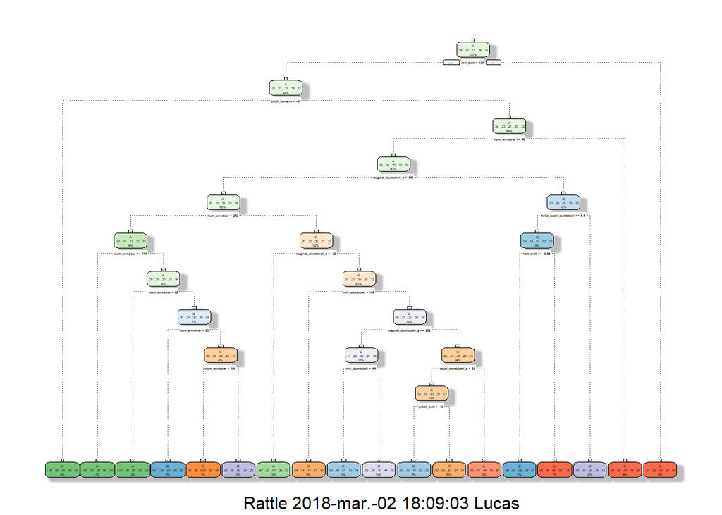

```r
modelDT <- rpart(classe ~ ., data = train, method = "class")
fancyRpartPlot(modelDT)
```

```r
predictDT <- predict(modelDT, test, type = "class")
confMatDT <- confusionMatrix(predictDT, test$classe)
confMatDT
```

```
## Confusion Matrix and Statistics
##
##           Reference
## Prediction    A    B    C    D    E
##          A 1466  139   34   54   11
##          B   58  691   37   36   24
##          C   34   90  837  173   46
##          D  109  192  111  614  205
##          E    7   27    7   87  796
##
## Overall Statistics
##
##                Accuracy : 0.7483
##                  95% CI : (0.737, 0.7594)
##     No Information Rate : 0.2845
##     P-Value [Acc > NIR] : < 2.2e-16
##
##                   Kappa : 0.6821
##  Mcnemar's Test P-Value : < 2.2e-16
##
## Statistics by Class:
##
##                      Class: A Class: B Class: C Class: D Class: E
## Sensitivity            0.8757   0.6067   0.8158   0.6369   0.7357
## Specificity            0.9435   0.9673   0.9294   0.8746   0.9733
## Pos Pred Value         0.8603   0.8168   0.7093   0.4988   0.8615
## Neg Pred Value         0.9503   0.9111   0.9598   0.9248   0.9424
## Prevalence             0.2845   0.1935   0.1743   0.1638   0.1839
## Detection Rate         0.2491   0.1174   0.1422   0.1043   0.1353
## Detection Prevalence   0.2895   0.1438   0.2005   0.2092   0.1570
## Balanced Accuracy      0.9096   0.7870   0.8726   0.7558   0.8545
```

### Random Forest

```r
control <- trainControl(method = "cv", number = 4, verboseIter=FALSE)
modelRF <- train(classe ~ ., data = train, method = "rf", trControl = control,ntree=250)
modelRF$finalModel
```

```
##
## Call:
##  randomForest(x = x, y = y, ntree = 250, mtry = param$mtry)
##                Type of random forest: classification
##                      Number of trees: 250
## No. of variables tried at each split: 27
##
##         OOB estimate of  error rate: 0.24%
## Confusion matrix:
##      A    B    C    D    E  class.error
## A 3905    1    0    0    0 0.0002560164
## B    5 2648    3    2    0 0.0037622272
## C    0    6 2389    1    0 0.0029215359
## D    0    0   11 2240    1 0.0053285968
## E    0    1    0    2 2522 0.0011881188
```

```r
predictRF <- predict(modelRF, test)
confMatRF <- confusionMatrix(predictRF, test$classe)
confMatRF
```

```
## Confusion Matrix and Statistics
##
##           Reference
## Prediction    A    B    C    D    E
##          A 1673    1    0    0    0
##          B    0 1135    1    0    2
##          C    0    3 1024    5    0
##          D    0    0    1  959    2
##          E    1    0    0    0 1078
##
## Overall Statistics
##
##                Accuracy : 0.9973
##                  95% CI : (0.9956, 0.9984)
##     No Information Rate : 0.2845
##     P-Value [Acc > NIR] : < 2.2e-16
##
##                   Kappa : 0.9966
##  Mcnemar's Test P-Value : NA
##
## Statistics by Class:
##
##                      Class: A Class: B Class: C Class: D Class: E
## Sensitivity            0.9994   0.9965   0.9981   0.9948   0.9963
## Specificity            0.9998   0.9994   0.9984   0.9994   0.9998
## Pos Pred Value         0.9994   0.9974   0.9922   0.9969   0.9991
## Neg Pred Value         0.9998   0.9992   0.9996   0.9990   0.9992
## Prevalence             0.2845   0.1935   0.1743   0.1638   0.1839
## Detection Rate         0.2843   0.1929   0.1740   0.1630   0.1832
## Detection Prevalence   0.2845   0.1934   0.1754   0.1635   0.1833
## Balanced Accuracy      0.9996   0.9979   0.9982   0.9971   0.9980
```

As Random Forest offers the maximum accuracy above 99%, we will go with Random Forest Model to predict our test data class variable.

## Predicting Test Set Output

The final result of our prediction:

```r
predictRFF <- predict(modelRF, testing)
predictRFF
```

```
##  [1] B A B A A E D B A A B C B A E E A B B B
## Levels: A B C D E
```